# PPG Paint Colors: Final Project Regression

Sai Vivek Chava

2023-12-12

```r
library(tidyverse, tidymodels)
library(caret)
df <- readr::read_csv("paint_project_train_data.csv", col_names = TRUE, show_col_types = F)
df %>% glimpse()
```

```
## Rows: 835
## Columns: 8
## $ R          <dbl> 172, 26, 172, 28, 170, 175, 90, 194, 171, 122, 0, 88, 144, …
## $ G          <dbl> 58, 88, 94, 87, 66, 89, 78, 106, 68, 151, 121, 140, 82, 163…
## $ B          <dbl> 62, 151, 58, 152, 58, 65, 136, 53, 107, 59, 88, 58, 132, 50…
## $ Lightness  <chr> "dark", "dark", "dark", "dark", "dark", "dark", "dark", "da…
## $ Saturation <chr> "bright", "bright", "bright", "bright", "bright", "bright",…
## $ Hue        <dbl> 4, 31, 8, 32, 5, 6, 34, 10, 1, 21, 24, 22, 36, 16, 26, 12, …
## $ response   <dbl> 12, 10, 16, 10, 11, 16, 10, 19, 14, 25, 14, 19, 14, 38, 15,…
## $ outcome    <dbl> 1, 1, 1, 0, 0, 0, 0, 0, 0, 0, 0, 0, 0, 0, 0, 0, 0, 0, 1, 1,…
```

```r
dfii <- df %>%
  mutate(y = boot::logit( (response - 0) / (100 - 0) ) ) %>%
  select(R, G, B,
         Lightness, Saturation, Hue,
         y, outcome)

dfii %>% glimpse()
```

```
## Rows: 835
## Columns: 8
## $ R          <dbl> 172, 26, 172, 28, 170, 175, 90, 194, 171, 122, 0, 88, 144, …
## $ G          <dbl> 58, 88, 94, 87, 66, 89, 78, 106, 68, 151, 121, 140, 82, 163…
## $ B          <dbl> 62, 151, 58, 152, 58, 65, 136, 53, 107, 59, 88, 58, 132, 50…
## $ Lightness  <chr> "dark", "dark", "dark", "dark", "dark", "dark", "dark", "da…
## $ Saturation <chr> "bright", "bright", "bright", "bright", "bright", "bright",…
## $ Hue        <dbl> 4, 31, 8, 32, 5, 6, 34, 10, 1, 21, 24, 22, 36, 16, 26, 12, …
## $ y          <dbl> -1.9924302, -2.1972246, -1.6582281, -2.1972246, -2.0907411,…
## $ outcome    <dbl> 1, 1, 1, 0, 0, 0, 0, 0, 0, 0, 0, 0, 0, 0, 0, 0, 0, 0, 1, 1,…
```

### Data Preprocessing

```r
# Train - test split
set.seed(12321)

train_id <- sample(1:nrow(dfii), size = floor(0.8 * nrow(dfii)))

df_train <- dfii %>% slice(train_id)

df_test <- dfii %>% slice(-train_id)

df_train_reg <- df_train %>% select(-outcome)
df_test_reg <- df_test %>% select(-outcome)
```

```r
cols_num <- c("R", "G", "B", "Hue")
var_mean <- as.vector(apply(df_train[,cols_num], 2, mean))
var_sd <- as.vector(apply(df_train[,cols_num], 2, sd))
df_train_stan  <- df_train[,cols_num] %>% scale(center = var_mean, scale = var_sd) %>%
  as.data.frame() %>% tibble::as_tibble() %>% bind_cols(df_train[,c('Lightness', 'Saturation', 'y')])

df_train_stan %>% glimpse()
```

```
## Rows: 668
## Columns: 7
## $ R          <dbl> 0.67589983, 0.74682922, 0.64043513, -2.23220550, 0.17939404…
## $ G          <dbl> 1.00129518, 0.64055891, 0.29986353, -1.90463595, 1.08145880…
## $ B          <dbl> 0.8835790, 0.7353264, -0.8398578, -1.3587420, 1.3283369, -0…
## $ Hue        <dbl> 0.34544316, -1.04226494, -0.05104487, 1.03929721, 0.9401752…
## $ Lightness  <chr> "light", "soft", "saturated", "dark", "soft", "midtone", "s…
## $ Saturation <chr> "subdued", "neutral", "muted", "neutral", "pure", "neutral"…
## $ y          <dbl> 1.04596856, 0.66329422, 0.08004271, -2.58668934, 1.09861229…
```

```r
df_test_stan <- df_test[,cols_num] %>% scale(center = var_mean, scale = var_sd) %>%
  as.data.frame() %>% tibble::as_tibble() %>% bind_cols(df_test[,c('Lightness', 'Saturation', 'y')])
df_test_stan %>% glimpse()
```

```
## Rows: 167
## Columns: 7
## $ R          <dbl> -0.22845000, -2.81737303, 0.16166169, -1.71796736, 0.161661…
## $ G          <dbl> -2.3856177, -1.7843905, -1.4236542, -0.7422635, -1.0027953,…
## $ B          <dbl> -1.8220315, -0.1727210, -1.9888157, -1.8961578, -1.9332210,…
## $ Hue        <dbl> -1.33963096, 1.33666323, -0.74489892, 0.44456517, -0.546654…
## $ Lightness  <chr> "dark", "dark", "dark", "dark", "dark", "dark", "dark", "da…
## $ Saturation <chr> "bright", "bright", "bright", "bright", "bright", "bright",…
## $ y          <dbl> -1.9924302, -2.1972246, -1.4500102, -1.4500102, -1.0986123,…
```

# Regression

## Linear models

```r
#Intercept only model no INPUTS
lm_intercept <- lm(y~1, data = df_train_stan)

#Categorical variables only linear additive
lm_category <- lm(y~Saturation + Lightness, data = df_train_stan)

#Continuous variables only linear additive
lm_continuous <- lm(y~R+G+B+Hue , data = df_train_stan)

#All categorical and continuous variables linear additive
lm_all_linear <- lm(y~. , data = df_train_stan )

#Interaction of the categorical inputs with all continuous inputs main effects
lm_cat_interaction <- lm(y~ Saturation*(R+G+B+Hue)+ Lightness *(R+G+B+Hue), data = df_train_stan)

#Add categorical inputs to all main effect and all pairwise interactions of continuous
lm_cat_lin <- lm(y~Saturation+Lightness+(R+G+B+Hue)^2, data= df_train_stan)

# Interaction of the categorical inputs with all main effect and all pairwise interactions of continuous inputs
lm_cat_pairwise <- lm(y~Saturation*(R+G+B+Hue)^2 +Lightness*(R+G+B+Hue)^2, data= df_train_stan)

# Interaction of Splines of Hue with 5 DoF with the linear and quadratic continuous variables and categorical
lm_basis_1 <- lm(y~(splines:: ns(Hue,5)) *(R+G+B+I(R^2)+I(G^2)+I(B^2)+Saturation+Lightness),
                 data = df_train_stan )

# interaction of splines of Hue with 5 DoF, linear additives of R,G,B, Lightness and Saturation
lm_basis_2 <- lm(y~(splines:: ns(Hue,5)) *(R+G+B+Lightness) * Saturation,
                 data = df_train_stan )

# Interaction between the Categorical and linear additives of Continuous variables
lm_basis_3 <- lm(y~(R+G+B+Hue)*Saturation*Lightness, data = df_train_stan )
```

```r
summary_model <- tibble()
lm_list <- c('lm_intercept','lm_category','lm_continuous','lm_all_linear','lm_cat_interaction',
             'lm_cat_lin','lm_cat_pairwise','lm_basis_1','lm_basis_2','lm_basis_3')
 for (i in lm_list){
   result <-broom::glance(get(i))
   rmse <- modelr::rmse(get(i), df_train_stan)
   summary_model <- bind_rows(summary_model,tibble(Model=i,rmse=rmse, result))

 }

summary_model
```

```
## # A tibble: 10 × 14
##    Model   rmse r.squared adj.r.squared  sigma statistic    p.value    df logLik
##    <chr>  <dbl>     <dbl>         <dbl>  <dbl>     <dbl>      <dbl> <dbl>  <dbl>
##  1 lm_i… 1.17       0             0     1.17         NA  NA            NA -1054.
##  2 lm_c… 0.403      0.882         0.880 0.407       408.  2.22e-294    12  -340.
##  3 lm_c… 0.126      0.988         0.988 0.127     14176.  0             4   436.
##  4 lm_a… 0.0880     0.994         0.994 0.0892     7177.  0            16   675.
##  5 lm_c… 0.0551     0.998         0.998 0.0580     4251.  0            64   988.
##  6 lm_c… 0.0778     0.996         0.995 0.0792     6623.  0            22   758.
##  7 lm_c… 0.0399     0.999         0.999 0.0451     3182.  0           142  1203.
##  8 lm_b… 0.0509     0.998         0.998 0.0559     2598.  0           113  1042.
##  9 lm_b… 0.0366     0.999         0.997 0.0600      607.  3.14e-280   419  1262.
## 10 lm_b… 0.0404     0.999         0.998 0.0507     1461.  0           244  1196.
## # ℹ 5 more variables: AIC <dbl>, BIC <dbl>, deviance <dbl>, df.residual <int>,
## #   nobs <int>
```

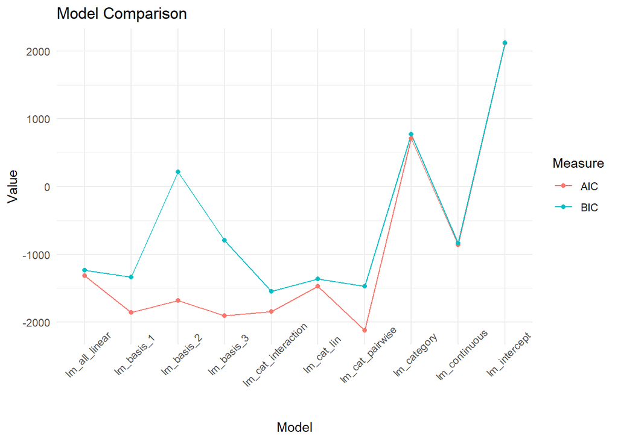

```r
summary_model %>% gather(Measure, Value,AIC, BIC) %>%
  ggplot(mapping = aes(x=Model, y=Value, color = Measure, group=Measure)) +
  geom_line()+  labs(title = "Model Comparison", x = "Model", y = "Value") +
  geom_point(aes(Model))+
  theme_minimal() +
  theme(axis.text.x = element_text(angle = 45))
```

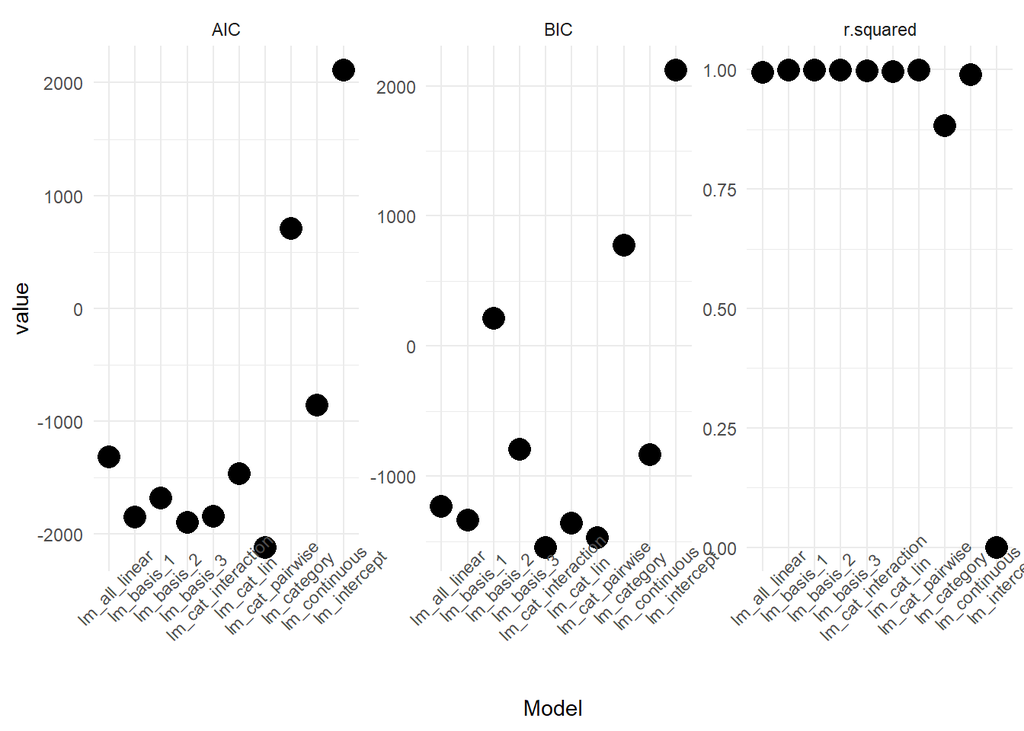

```r
summary_model %>%
  select(Model, df, r.squared, AIC, BIC) %>%
  pivot_longer(!c("Model", "df")) %>%
  ggplot(mapping = aes(x = Model, y = value)) +
  geom_point(size = 5) +
  facet_wrap(~name, scales = "free_y") +
  theme_minimal()+
  theme(axis.text.x = element_text(angle = 45))
```

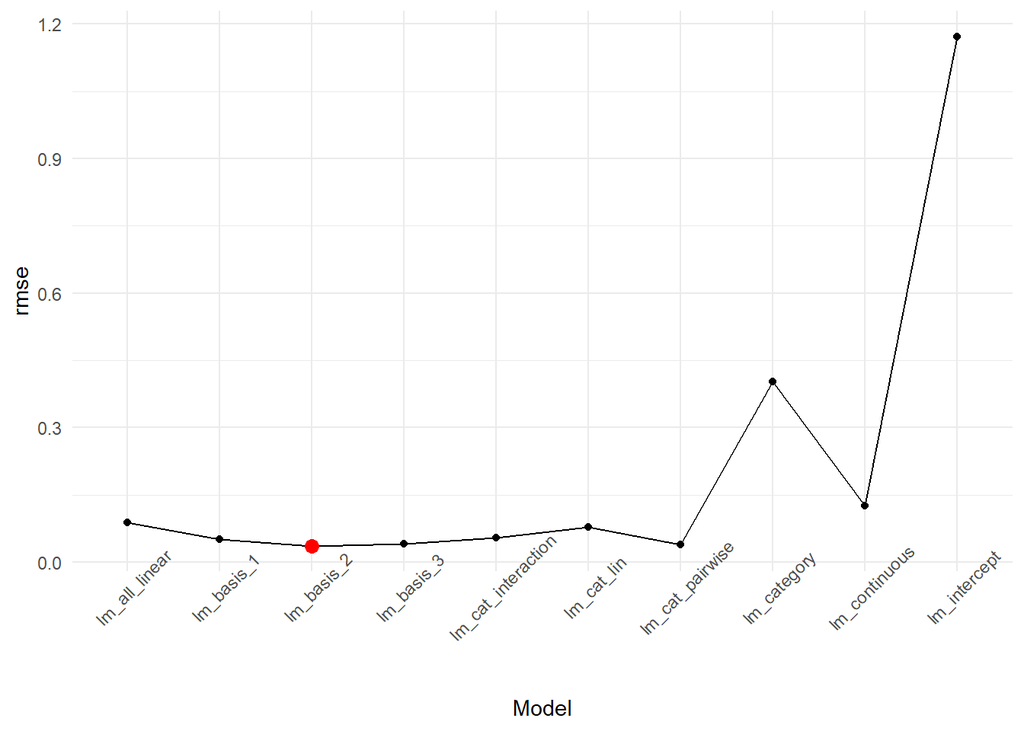

```r
summary_model %>% ggplot(mapping = aes(Model, rmse, group=1))+
  geom_line()+geom_point() + theme_minimal()+
  geom_point(data = summary_model[which.min(summary_model$rmse), , drop = FALSE],color = "red", size = 3) +
  theme(axis.text.x = element_text(angle = 45))
```

**Which of the 10 models is the best?**

**What performance metric did you use to make your selection**

**Visualize the coefficient summaries for your top 3 models**

```r
summary(lm_cat_lin)
```

```
##
## Call:
## lm(formula = y ~ Saturation + Lightness + (R + G + B + Hue)^2,
##     data = df_train_stan)
##
## Residuals:
##       Min        1Q    Median        3Q       Max
## -0.278280 -0.049308 -0.004649  0.042704  0.293803
##
## Coefficients:
##                     Estimate Std. Error t value Pr(>|t|)
## (Intercept)        -0.126788   0.024719  -5.129 3.85e-07 ***
## Saturationgray     -0.047756   0.014961  -3.192 0.001481 **
## Saturationmuted    -0.022128   0.011284  -1.961 0.050316 .
## Saturationneutral  -0.054939   0.012509  -4.392 1.31e-05 ***
## Saturationpure      0.030403   0.012019   2.530 0.011658 *
## Saturationshaded   -0.045141   0.011934  -3.783 0.000170 ***
## Saturationsubdued  -0.048973   0.011675  -4.195 3.11e-05 ***
## Lightnessdeep       0.056829   0.014398   3.947 8.79e-05 ***
## Lightnesslight     -0.075537   0.033497  -2.255 0.024466 *
## Lightnessmidtone   -0.094725   0.025602  -3.700 0.000234 ***
## Lightnesspale       0.042454   0.035547   1.194 0.232800
## Lightnesssaturated -0.004038   0.019863  -0.203 0.838972
## Lightnesssoft      -0.106806   0.029880  -3.575 0.000377 ***
## R                   0.274768   0.009002  30.523  < 2e-16 ***
## G                   0.875967   0.011700  74.870  < 2e-16 ***
## B                   0.162758   0.010047  16.199  < 2e-16 ***
## Hue                -0.006174   0.006913  -0.893 0.372136
## R:G                 0.034044   0.006317   5.389 9.93e-08 ***
## R:B                -0.011704   0.009597  -1.220 0.223083
## R:Hue              -0.042819   0.009278  -4.615 4.74e-06 ***
## G:B                 0.062276   0.008253   7.546 1.54e-13 ***
## G:Hue               0.032221   0.011046   2.917 0.003657 **
## B:Hue               0.004098   0.013911   0.295 0.768412
## ---
## Signif. codes:  0 '***' 0.001 '**' 0.01 '*' 0.05 '.' 0.1 ' ' 1
##
## Residual standard error: 0.07921 on 645 degrees of freedom
## Multiple R-squared:  0.9956, Adjusted R-squared:  0.9954
## F-statistic:  6623 on 22 and 645 DF,  p-value: < 2.2e-16
```

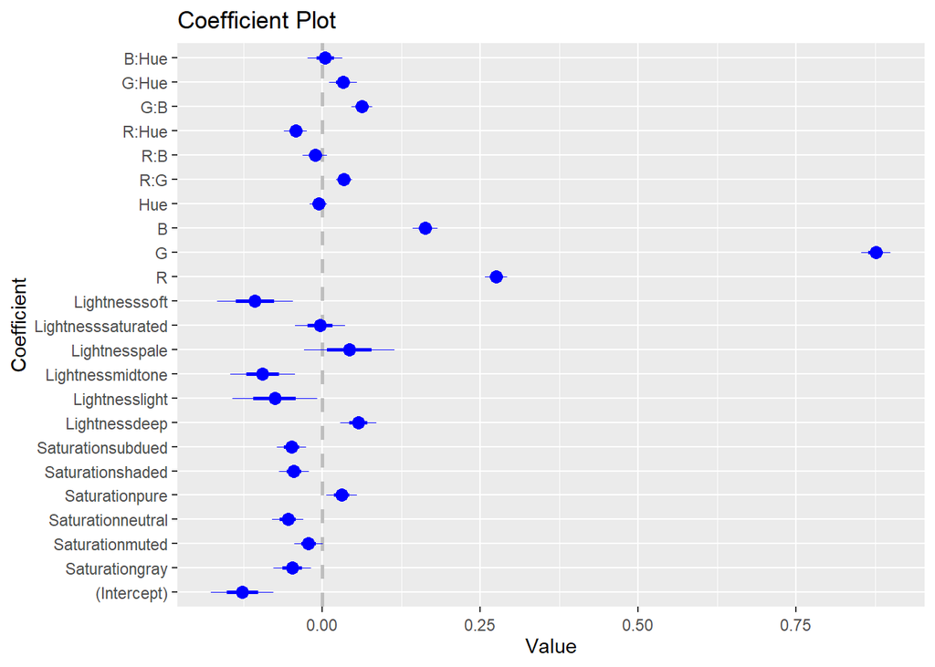

```r
lm_cat_lin %>% coefplot::coefplot()
```

```r
summary(lm_cat_interaction)
```

```
##
## Call:
## lm(formula = y ~ Saturation * (R + G + B + Hue) + Lightness *
##     (R + G + B + Hue), data = df_train_stan)
##
## Residuals:
##       Min        1Q    Median        3Q       Max
## -0.256238 -0.032995 -0.001883  0.028612  0.242048
##
## Coefficients:
##                          Estimate Std. Error t value Pr(>|t|)
## (Intercept)            -0.0648173  0.0456569  -1.420 0.156223
## Saturationgray         -0.0529856  0.0163527  -3.240 0.001260 **
## Saturationmuted        -0.0361441  0.0084439  -4.280 2.17e-05 ***
## Saturationneutral      -0.0687995  0.0090839  -7.574 1.37e-13 ***
## Saturationpure          0.0599035  0.0096941   6.179 1.19e-09 ***
## Saturationshaded       -0.0604396  0.0085990  -7.029 5.66e-12 ***
## Saturationsubdued      -0.0560581  0.0086267  -6.498 1.70e-10 ***
## R                       0.2081878  0.0114708  18.149  < 2e-16 ***
## G                       0.7523658  0.0159265  47.240  < 2e-16 ***
## B                       0.1989456  0.0240369   8.277 8.16e-16 ***
## Hue                    -0.0738942  0.0126866  -5.825 9.32e-09 ***
## Lightnessdeep          -0.1161435  0.0462167  -2.513 0.012230 *
## Lightnesslight         -0.3963759  0.0569337  -6.962 8.78e-12 ***
## Lightnessmidtone       -0.1080877  0.0468143  -2.309 0.021289 *
## Lightnesspale          -0.6991201  0.0688954 -10.148  < 2e-16 ***
## Lightnesssaturated     -0.0806047  0.0458642  -1.757 0.079346 .
## Lightnesssoft          -0.1831617  0.0484749  -3.778 0.000173 ***
## Saturationgray:R       -0.2048484  0.0913937  -2.241 0.025364 *
## Saturationmuted:R      -0.0243293  0.0154570  -1.574 0.116012
## Saturationneutral:R     0.1092836  0.0393295   2.779 0.005628 **
## Saturationpure:R        0.0115342  0.0118423   0.974 0.330454
## Saturationshaded:R      0.0019010  0.0264408   0.072 0.942709
## Saturationsubdued:R     0.0171567  0.0198152   0.866 0.386925
## Saturationgray:G        0.3487611  0.1024834   3.403 0.000710 ***
## Saturationmuted:G       0.0497493  0.0182396   2.728 0.006567 **
## Saturationneutral:G    -0.0522447  0.0480394  -1.088 0.277234
## Saturationpure:G        0.0310118  0.0146296   2.120 0.034431 *
## Saturationshaded:G      0.0682952  0.0310402   2.200 0.028170 *
## Saturationsubdued:G     0.0248469  0.0234045   1.062 0.288830
```

[output cut: 27 more lines]

```
## B:Lightnesspale         0.0176709  0.0410919   0.430 0.667324
## B:Lightnesssaturated   -0.0660415  0.0273583  -2.414 0.016078 *
## B:Lightnesssoft        -0.0771505  0.0281643  -2.739 0.006339 **
## Hue:Lightnessdeep       0.0510678  0.0135298   3.774 0.000176 ***
## Hue:Lightnesslight      0.0667476  0.0130690   5.107 4.39e-07 ***
## Hue:Lightnessmidtone    0.0600169  0.0147299   4.074 5.23e-05 ***
## Hue:Lightnesspale       0.0680845  0.0135325   5.031 6.44e-07 ***
## Hue:Lightnesssaturated  0.0444549  0.0135827   3.273 0.001125 **
## Hue:Lightnesssoft       0.0640875  0.0138442   4.629 4.50e-06 ***
## ---
## Signif. codes:  0 '***' 0.001 '**' 0.01 '*' 0.05 '.' 0.1 ' ' 1
##
## Residual standard error: 0.05803 on 603 degrees of freedom
## Multiple R-squared:  0.9978, Adjusted R-squared:  0.9976
## F-statistic:  4251 on 64 and 603 DF,  p-value: < 2.2e-16
```

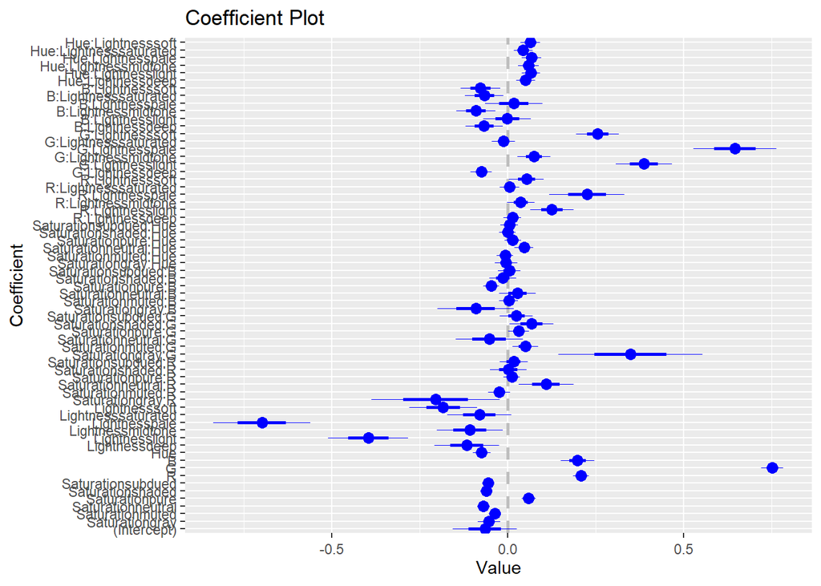

```r
lm_cat_interaction %>% coefplot::coefplot()
```

```r
summary(lm_cat_pairwise)
```

```
##
## Call:
## lm(formula = y ~ Saturation * (R + G + B + Hue)^2 + Lightness *
##     (R + G + B + Hue)^2, data = df_train_stan)
##
## Residuals:
##       Min        1Q    Median        3Q       Max
## -0.224177 -0.022356 -0.001758  0.022232  0.191667
##
## Coefficients:
##                            Estimate Std. Error t value Pr(>|t|)
## (Intercept)              -0.2509084  0.1038796  -2.415 0.016059 *
## Saturationgray           -0.0722677  0.0396112  -1.824 0.068656 .
## Saturationmuted          -0.0301106  0.0341195  -0.883 0.377907
## Saturationneutral        -0.0424300  0.0342079  -1.240 0.215397
## Saturationpure            0.0481200  0.0419576   1.147 0.251958
## Saturationshaded         -0.0125528  0.0344001  -0.365 0.715328
## Saturationsubdued        -0.0576913  0.0350479  -1.646 0.100347
## R                         0.1250037  0.0537597   2.325 0.020440 *
## G                         0.6573803  0.0561834  11.701  < 2e-16 ***
## B                         0.0999991  0.0604892   1.653 0.098894 .
## Hue                      -0.1409505  0.0637634  -2.211 0.027499 *
## Lightnessdeep             0.0408593  0.1056491   0.387 0.699102
## Lightnesslight            0.1079370  0.1255491   0.860 0.390336
## Lightnessmidtone          0.0292477  0.1052112   0.278 0.781129
## Lightnesspale             0.5707032  0.1927280   2.961 0.003203 **
## Lightnesssaturated        0.0379633  0.1033869   0.367 0.713620
## Lightnesssoft             0.0434447  0.1060247   0.410 0.682149
## R:G                      -0.0434537  0.0200818  -2.164 0.030927 *
## R:B                      -0.0492650  0.0297209  -1.658 0.097998 .
## R:Hue                    -0.0257271  0.0487358  -0.528 0.597800
## G:B                      -0.0172827  0.0434164  -0.398 0.690741
## G:Hue                     0.0090460  0.0349852   0.259 0.796072
## B:Hue                    -0.0886005  0.0463119  -1.913 0.056275 .
## Saturationgray:R         -0.2484135  0.1150548  -2.159 0.031296 *
## Saturationmuted:R        -0.0134646  0.0374252  -0.360 0.719161
## Saturationneutral:R       0.0567925  0.0580470   0.978 0.328333
## Saturationpure:R          0.0203650  0.0418978   0.486 0.627125
## Saturationshaded:R       -0.0388727  0.0450987  -0.862 0.389110
## Saturationsubdued:R       0.0132222  0.0466887   0.283 0.777135
```

[output cut: 105 more lines]

```
## G:Hue:Lightnesspale       0.1265067  0.0901143   1.404 0.160955
## G:Hue:Lightnesssaturated  0.0888266  0.0312918   2.839 0.004706 **
## G:Hue:Lightnesssoft       0.1666458  0.0451718   3.689 0.000248 ***
## B:Hue:Lightnessdeep      -0.0173231  0.0351711  -0.493 0.622545
## B:Hue:Lightnesslight     -0.1062042  0.0672948  -1.578 0.115123
## B:Hue:Lightnessmidtone    0.0095906  0.0484353   0.198 0.843116
## B:Hue:Lightnesspale      -0.0255918  0.0934673  -0.274 0.784343
## B:Hue:Lightnesssaturated  0.0788915  0.0382036   2.065 0.039411 *
## B:Hue:Lightnesssoft      -0.0200390  0.0531786  -0.377 0.706457
## ---
## Signif. codes:  0 '***' 0.001 '**' 0.01 '*' 0.05 '.' 0.1 ' ' 1
##
## Residual standard error: 0.04506 on 525 degrees of freedom
## Multiple R-squared:  0.9988, Adjusted R-squared:  0.9985
## F-statistic:  3182 on 142 and 525 DF,  p-value: < 2.2e-16
```

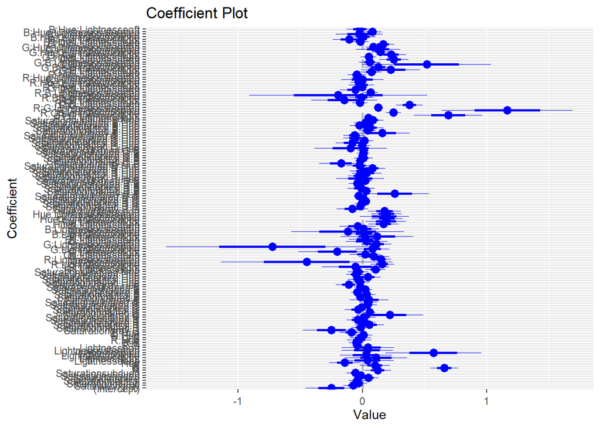

```r
lm_cat_pairwise %>% coefplot::coefplot()
```

**How do the coefficient summaries compare between the top 3 models?**

Despite the fact that the model `lm_cat_pairwise` has more complex interactions, it do not have as many statistically significant values as that of `lm_cat_lin` and `lm_cat_interaction` respectively.

**Which inputs seem important?**

The Inputs `R,G,B` seems to be more important as they have the highest significant codes along with few levels of Saturation and Lightness as per the best model. The Hue didn’t seem to have significant imapact. `Saturationneutral, Saturationshaded ,Saturationsubdued, Lightnessdeep` have higher significant codes. Not all levels of saturation and lightness have important features.

# Bayesian Linear Models

```r
blm_1 <- model.matrix(formula(lm_cat_lin), data = df_train_stan)
info_blm_1 <- list(yobs = df_train$y,
  design_matrix = blm_1,
  mu_beta = 0 ,
  tau_beta = 4,
  sigma_rate =1 )
```

**State why you chose the second model.**

```r
blm_2 <- model.matrix(formula(lm_cat_interaction), data = df_train_stan)
info_blm_2 <- list(yobs = df_train$y,
  design_matrix = blm_2,
  mu_beta = 0 ,
  tau_beta = 4,
  sigma_rate =1 )
```

```r
dim(blm_1)
```

```
## [1] 668  23
```

```r
dim(blm_2)
```

```
## [1] 668  65
```

```r
lm_logpost <- function(unknowns, my_info)
{
  # specify the number of unknown beta parameters
  length_beta <- ncol(my_info$design_matrix)

  # extract the beta parameters from the `unknowns` vector
  beta_v <- unknowns[1:length_beta]

  # extract the unbounded noise parameter, varphi
  lik_varphi <- unknowns[length_beta + 1]

  # back-transform from varphi to sigma
  lik_sigma <- exp(lik_varphi)

  # extract design matrix
  X <-  my_info$design_matrix
  #print(X)

  # calculate the linear predictor
  mu <- as.vector(X %*% as.matrix(beta_v))
  #print(mu)

  # evaluate the log-likelihood
  log_lik <- sum(dnorm(x = my_info$yobs,
                       mean = mu,
                       sd = lik_sigma,
                       log = TRUE))


  # evaluate the log-prior
  log_prior_beta <-  sum(dnorm(x = beta_v,
                              mean = my_info$mu_beta,
                              sd = my_info$tau_beta,
                              log = TRUE))

   log_prior_sigma <- dexp(x = lik_sigma,
                          rate = my_info$sigma_rate,
                          log = TRUE)

  # add the mean trend prior and noise prior together
  log_prior <- log_prior_beta + log_prior_sigma

  # account for the transformation
  log_derive_adjust <- lik_varphi

  # sum together
  log_lik + log_prior + log_derive_adjust

}
```

```r
my_laplace <- function(start_guess, logpost_func, ...)
{
  # code adapted from the `LearnBayes`` function `laplace()`
  fit <- optim(start_guess,
               logpost_func,
               gr = NULL,
               ...,
               method = "BFGS",
               hessian = TRUE,
               control = list(fnscale = -1, maxit = 1001))

  mode <- fit$par
  post_var_matrix <- -solve(fit$hessian)
  p <- length(mode) # number of unknown parameters
  int <- p/2 * log(2*pi) + 1/2 * log(det(post_var_matrix)) + logpost_func(mode, ...)
  # package all of the results into a list
  list(mode = mode,
       var_matrix = post_var_matrix,
       log_evidence = int,
       converge = ifelse(fit$convergence == 0,
                         "YES",
                         "NO"),
       iter_counts = as.numeric(fit$counts[1]))
}
```

```r
laplace_lm_blm1 <- my_laplace(rep (0, ncol(blm_1)+1), lm_logpost, info_blm_1)
laplace_lm_blm2 <- my_laplace(rep (0, ncol(blm_2)+1), lm_logpost, info_blm_2)
```

**Best model Amongst the two**

```r
exp(laplace_lm_blm1$log_evidence)/sum(exp(laplace_lm_blm2$log_evidence))
```

```
## [1] 26886.7
```

The model `laplace_lm_blm1` seems to perform better than the model 2. As per the posterior model weights associated with the log evidence, the model 1 outperforms the model 2.

**Which performance metric did you use to make your selection?**

The performance metric chosen is `Evidence` or Marginal Likelihood.

**Visualize the regression coefficient posterior summary statistics for your best model.**

```r
viz_post_coefs <- function(post_means, post_sds, xnames)
{
  tibble::tibble(
    mu = post_means,
    sd = post_sds,
    x = xnames
  ) %>%
    mutate(x = factor(x, levels = xnames)) %>%
    ggplot(mapping = aes(x = x)) +
    geom_hline(yintercept = 0, color = 'grey', linetype = 'dashed') +
    geom_point(mapping = aes(y = mu)) +
    geom_linerange(mapping = aes(ymin = mu - 2 * sd,
                                 ymax = mu + 2 * sd,
                                 group = x)) +
    labs(x = 'feature', y = 'coefficient value') +
    coord_flip() +
    theme_bw()
}
```

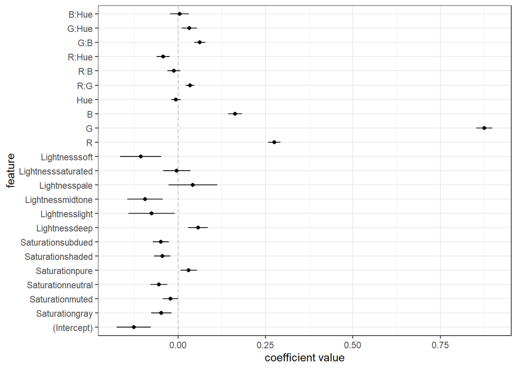

```r
viz_post_coefs(laplace_lm_blm1$mode[1:ncol(blm_1)], sqrt(diag(laplace_lm_blm1$var_matrix))[1:ncol(blm_1)], colnames(blm_1))
```

```r
viz_post_coefs <- function(post_means, post_sds, mle_sigma, xnames) {
  tibble::tibble(
    mu = post_means,
    sd = post_sds,
    term =  xnames
  ) %>%
    left_join(mle_sigma, by = 'term')%>%
    pivot_longer(c("mu", "mle")) %>%
    filter(term != '(Intercept)')  %>%
    ggplot(mapping = aes(y=value, x = term)) +
    geom_hline(yintercept = 0, color = 'grey', linetype = 'dashed') +
    geom_point(mapping = aes(color = name, shape=name), shape = 16, position = position_dodge(width = 0.2)) +  # Change shape for post_means points
    stat_summary(geom = 'linerange',
                 fun.max = 'max', fun.min = 'min',
                 mapping = aes(group = term),
                 color = 'black', linewidth = 1) +
    # geom_linerange(mapping = aes(ymin = mu - 2 * sd,
    #                              ymax = mu + 2 * sd,
    #                              group = term)) +
    labs(x = 'feature', y = 'coefficient value') +
    coord_flip() +
    theme_minimal()+
    scale_color_manual(name = "Legend", values = c("red", "black"), labels = c("MLE", "mu"))
}
```

**How does the lm() maximum likelihood estimate (MLE) on 𝜎relate to the posterior UNCERTAINTY on 𝜎? Do you feel the posterior is precise or are we quite uncertain about 𝜎**

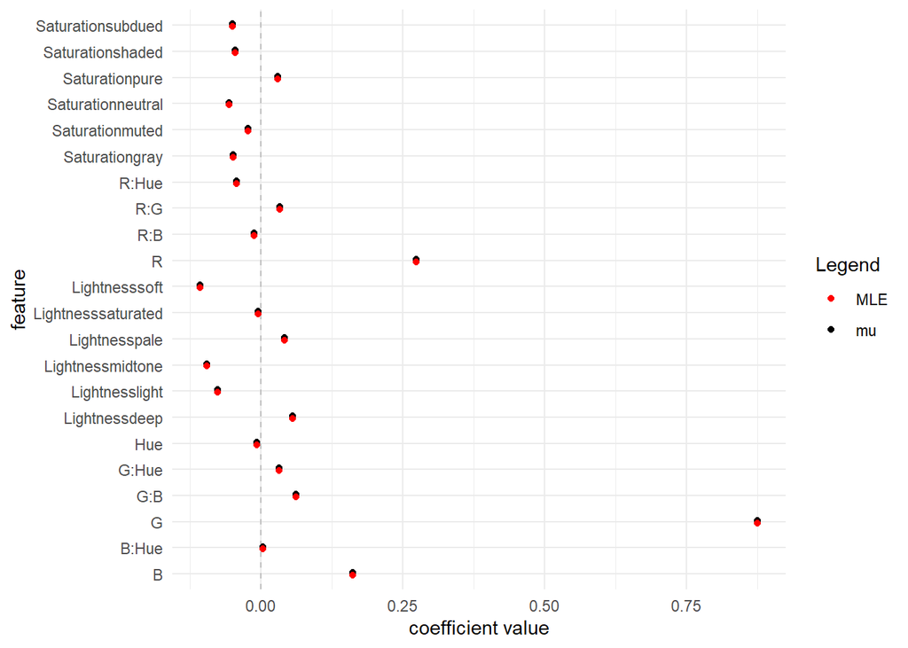

```r
mle_sigma_values <- broom::tidy(lm_cat_lin) %>% select(term, mle = estimate)


viz_post_coefs(laplace_lm_blm1$mode[1:ncol(blm_1)], sqrt(diag(laplace_lm_blm1$var_matrix))[1:ncol(blm_1)],
               mle_sigma_values, colnames(blm_1))
```

# Linear Model Predictions

#### Best model as per the Linear Models

```r
viz_grid_lm <- expand.grid(
  G = seq(round(min(df_train_stan$G),3),round(max(df_train_stan$G),3),length.out=101),
  B = seq(round(min(df_train_stan$B),3),round(max(df_train_stan$B),3),length.out=6),
                        R = median(df_train_stan$R),
                        Hue = median(df_train_stan$Hue),
                        Saturation = unique(df_train_stan$Saturation),
                        Lightness = unique(df_train_stan$Lightness),
                        KEEP.OUT.ATTRS = FALSE,
                        stringsAsFactors = FALSE) %>%
  as.data.frame() %>% tibble::as_tibble()
viz_grid_lm %>% glimpse()
```

```
## Rows: 29,694
## Columns: 6
## $ G          <dbl> -2.28500, -2.24933, -2.21366, -2.17799, -2.14232, -2.10665,…
## $ B          <dbl> -2.1, -2.1, -2.1, -2.1, -2.1, -2.1, -2.1, -2.1, -2.1, -2.1,…
## $ R          <dbl> 0.3567175, 0.3567175, 0.3567175, 0.3567175, 0.3567175, 0.35…
## $ Hue        <dbl> -0.05104487, -0.05104487, -0.05104487, -0.05104487, -0.0510…
## $ Saturation <chr> "subdued", "subdued", "subdued", "subdued", "subdued", "sub…
## $ Lightness  <chr> "light", "light", "light", "light", "light", "light", "ligh…
```

```r
tidy_predict <- function(mod, xnew)
{
  pred_df <- predict(mod, xnew, interval = "confidence") %>%
    as.data.frame() %>% tibble::as_tibble() %>%
    dplyr::select(pred = fit, ci_lwr = lwr, ci_upr = upr) %>%
    bind_cols(predict(mod, xnew, interval = 'prediction') %>%
                as.data.frame() %>% tibble::as_tibble() %>%
                dplyr::select(pred_lwr = lwr, pred_upr = upr))

  xnew %>% bind_cols(pred_df)
}
```

```r
lm_best_mod <- tidy_predict(lm_cat_lin, viz_grid_lm)
```

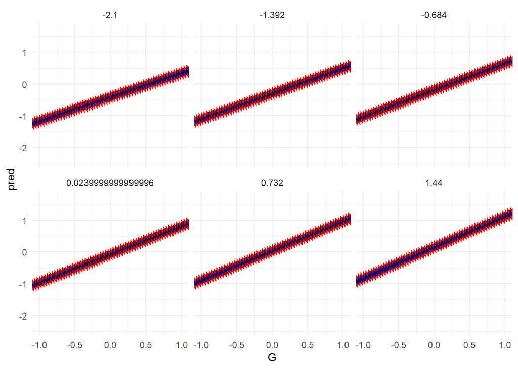

```r
lm_best_mod %>%
  ggplot( mapping = aes(x = G)) +
  geom_ribbon( mapping = aes(ymin = pred_lwr , ymax = pred_upr), fill = 'red') +
  geom_ribbon( mapping = aes( ymin = ci_lwr, ymax = ci_upr), fill = 'blue') +
  geom_line( mapping = aes(y = pred))  + facet_wrap(~B) + coord_cartesian((ylim = c(-1,1))) +
  theme_minimal()
```

In the plot above, it can be seen that the confidence interval is well with in the prediction interval.

#### Best Model as per Bayesian Models

```r
generate_lm_post_samples <- function(mvn_result, length_beta, num_samples)
{
  MASS::mvrnorm(n = num_samples,
                mu = mvn_result$mode,
                Sigma = mvn_result$var_matrix) %>%
    as.data.frame() %>% tibble::as_tibble() %>%
    purrr::set_names(c(sprintf("beta_%02d", 0:(length_beta-1)), "varphi")) %>%
    mutate(sigma = exp(varphi))
}
```

```r
post_lm_pred_samples <- function(Xnew, Bmat, sigma_vector)
{
  # number of new prediction locations
  M <- nrow(Xnew)
  # number of posterior samples
  S <- nrow(Bmat)

  # matrix of linear predictors
  Umat <- Xnew %*% t(Bmat)


  # assmeble matrix of sigma samples, set the number of rows
  Rmat <- matrix(rep(sigma_vector, M), nrow(Xnew) , byrow = TRUE)

  # generate standard normal and assemble into matrix
  # set the number of rows
  Zmat <- matrix(rnorm(M*S), nrow(Xnew) , byrow = TRUE)


  # calculate the random observation predictions
  Ymat <- Umat + Rmat * Zmat


  # package together
  list(Umat = Umat, Ymat = Ymat)
}
```

```r
make_post_lm_pred <- function(Xnew, post)
{
  Bmat <- post %>% dplyr::select(starts_with("beta")) %>% as.matrix()

  sigma_vector <- post %>% pull(sigma)

  post_lm_pred_samples(Xnew, Bmat, sigma_vector)
}
```

```r
summarize_lm_pred_from_laplace <- function(mvn_result, Xtest, num_samples)
{
  # generate posterior samples of the beta parameters
  post <- generate_lm_post_samples(mvn_result, ncol(Xtest), num_samples)
  #print('post')
  #print(dim(post))

  # make posterior predictions on the test set
  pred_test <- make_post_lm_pred(Xtest, post)

  # calculate summary statistics on the predicted mean and response
  # summarize over the posterior samples

  # posterior mean, should you summarize along rows (rowMeans) or
  # summarize down columns (colMeans) ???
  mu_avg <- rowMeans(pred_test$Umat)
  y_avg <- rowMeans(pred_test$Ymat)

  # posterior quantiles for the middle 95% uncertainty intervals
  mu_lwr <- apply(pred_test$Umat, 1, stats::quantile, probs = 0.025)
  mu_upr <- apply(pred_test$Umat, 1, stats::quantile, probs = 0.975)
  y_lwr <- apply(pred_test$Ymat, 1, stats::quantile, probs = 0.025)
  y_upr <- apply(pred_test$Ymat, 1, stats::quantile, probs = 0.975)

  # book keeping
  tibble::tibble(
    mu_avg = mu_avg,
    mu_lwr = mu_lwr,
    mu_upr = mu_upr,
    y_avg = y_avg,
    y_lwr = y_lwr,
    y_upr = y_upr
  ) %>%
    tibble::rowid_to_column("pred_id")
}
```

```r
#creating test design matrix
bayes_best_mod <- model.matrix(~Saturation + Lightness + (R + G + B + Hue)^2, data = viz_grid_lm)
# summarizing posterior predictions
post_pred_summary <- summarize_lm_pred_from_laplace(laplace_lm_blm1, bayes_best_mod, 5000)
```

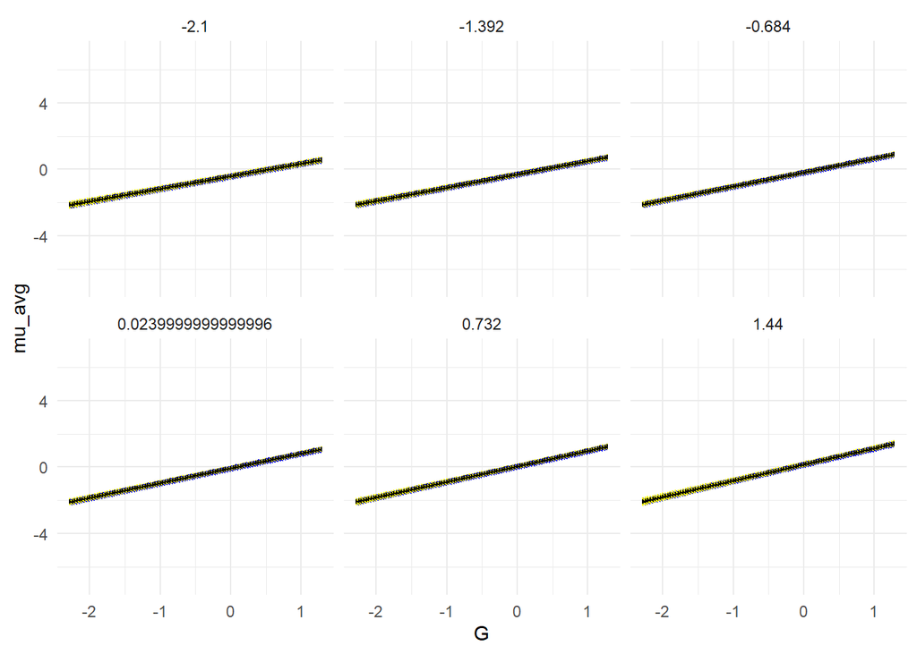

```r
post_pred_summary %>%
  left_join(viz_grid_lm %>% tibble::rowid_to_column("pred_id"),
            by = 'pred_id') %>% ggplot(mapping = aes(G)) +
  geom_ribbon(aes(ymin=y_lwr, ymax = y_upr), fill= 'blue') +
  geom_ribbon(aes(ymin= mu_lwr, ymax = mu_upr), color='yellow', fill='black')+
  geom_line(aes(y=mu_avg))+
  coord_cartesian(ylim = c(-7,7)) + facet_wrap(~B) + theme_minimal()
```

**You MUST state if the predictive trends are consistent between the 2 selected linear models.**

Upon observing the predictive trends of the both models, it can be said that both the models are consistent with their own prediction and confidence intervals but they are not same.

# Train/Tune with Resampling

#### Model 1

```r
my_ctrl_1 <- trainControl(method = 'repeatedcv', number = 10, repeats = 5, savePredictions = T)

my_metric <- 'RMSE'
```

**All categorical and continuous inputs linear additive features**

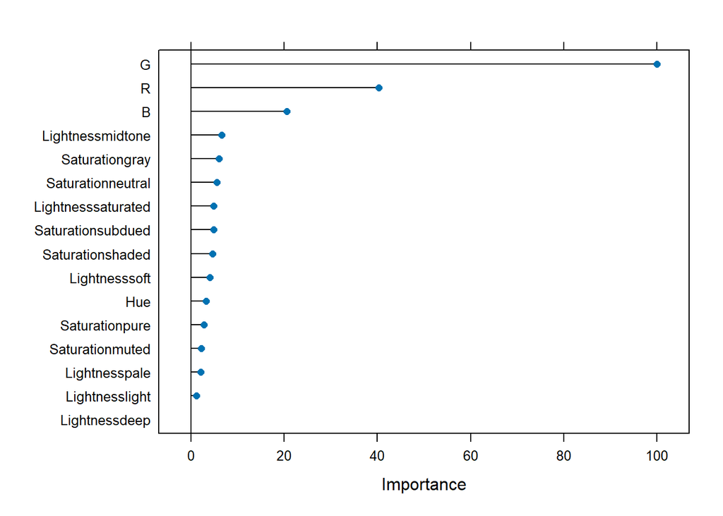

```r
set.seed(1256)

mod_1 <- train(formula(lm_all_linear), method='lm', trControl = my_ctrl_1,
               preProcess=c('center', 'scale'), metric= my_metric,
               data = df_train_reg)
mod_1 %>% readr::write_rds("reg_mod_1.rds")
plot(varImp(mod_1))
```

#### Model 2

**Add categorical inputs to all main effect and all pairwise interactions of continuous inputs**

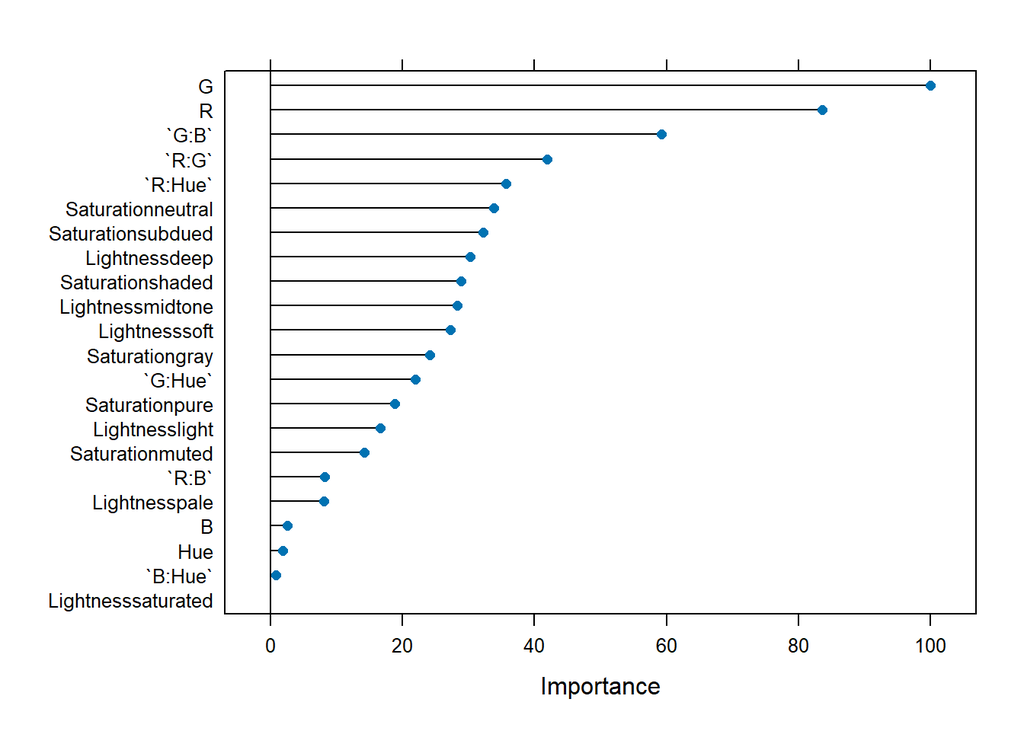

```r
set.seed(1245)
mod_2 <- train(formula(lm_cat_lin), method='lm', trControl = my_ctrl_1,
               preProcess= c('center', 'scale'), data= df_train_reg)
mod_2 %>% readr::write_rds("reg_mod_2.rds")
plot(varImp(mod_2))
```

#### Model 3

**Interaction of the categorical inputs with all continuous inputs main effects**

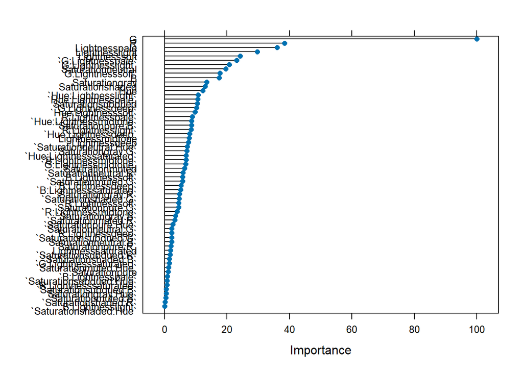

```r
set.seed(12343)
mod_3 <- train(formula(lm_cat_interaction), method= 'lm', trControl = my_ctrl_1,
               preProcess= c('center', 'scale'), data = df_train_reg)
mod_3 %>% readr::write_rds("reg_mod_3.rds")
plot(varImp(mod_3))
```

###Regularized regression with Elastic Net

#### Model 4

**Add categorical inputs to all main effect and all pairwise interactions of continuous inputs**

```r
set.seed(1234)
# training a default elastic net
enet_default <- train(formula(lm_cat_lin), method = 'glmnet', metric = my_metric, trControl = my_ctrl_1,
               preProcess= c('center', 'scale'), data = df_train_reg)
```

```r
lambda_grid <- exp(seq(log(min(enet_default$results$lambda)),
                          log(max(enet_default$results$lambda)), length.out = 25))
enet_grid <- expand.grid(alpha = seq(0.1,1, by=0.1),
                         lambda = lambda_grid)
```

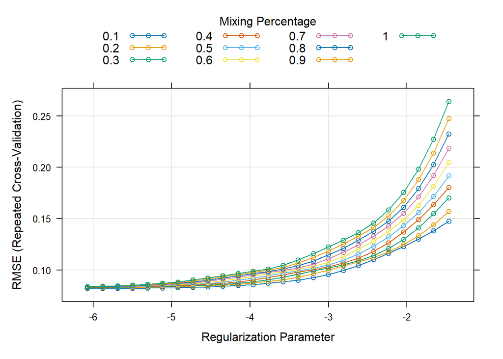

```r
set.seed(1234)

mod_4 <- train(formula(lm_cat_lin), method = 'glmnet', metric = my_metric, trControl = my_ctrl_1,
               preProcess= c('center', 'scale'), tuneGrid = enet_grid, data = df_train_reg)
mod_4 %>% readr::write_rds("reg_mod_4.rds")
plot(mod_4, xTrans=log)
```

```r
mod_4$bestTune
```

```
##   alpha      lambda
## 1   0.1 0.002302494
```

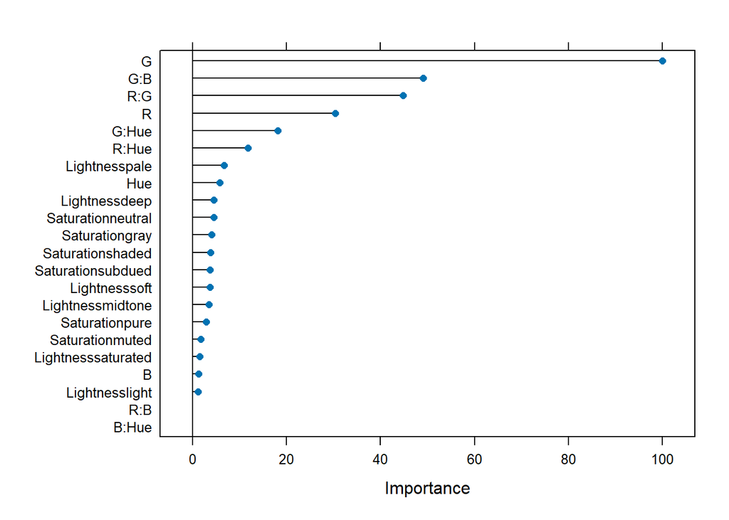

```r
plot(varImp(mod_4))
```

Not many features have been muted.

#### Model 5

**Interaction of the categorical inputs with all continuous inputs main effects**

```r
set.seed(12345)
# training a default elastic net
enet_1_default <- train(formula(lm_cat_interaction), method = 'glmnet', metric = my_metric,
                         trControl = my_ctrl_1, preProcess= c('center', 'scale'), data = df_train_reg)

lambda_grid <- exp(seq(log(min(enet_1_default$results$lambda)),
                          log(max(enet_1_default$results$lambda)), length.out = 25))
enet_grid <- expand.grid(alpha = seq(0.1,1, by=0.1),
                         lambda = lambda_grid)
```

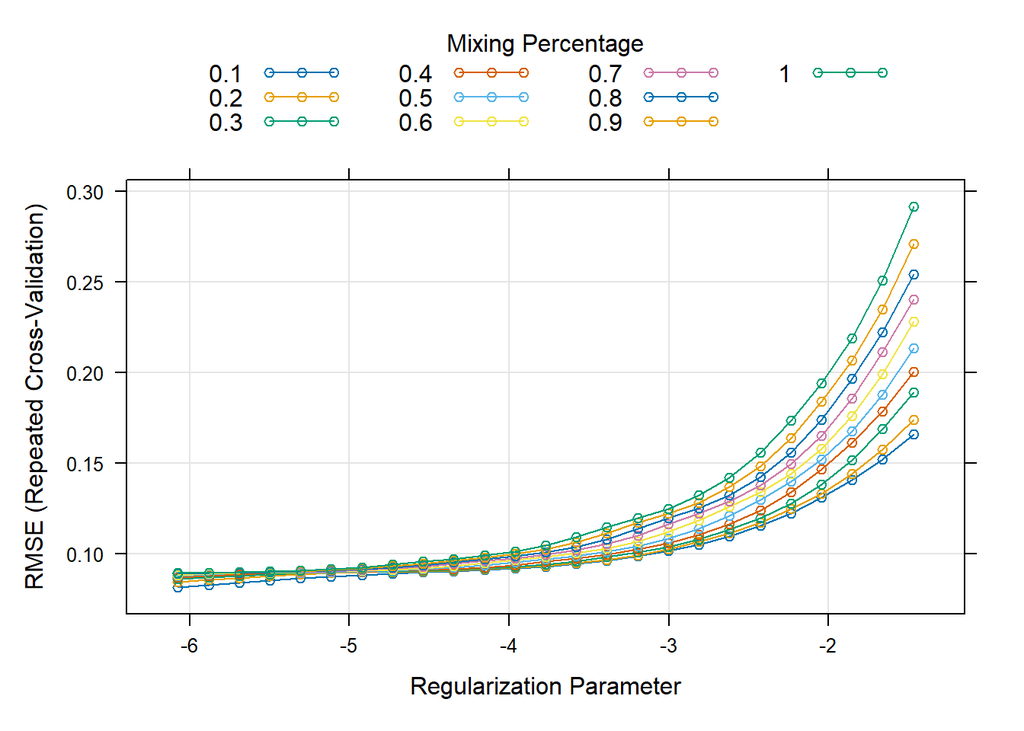

```r
set.seed(12335)
mod_5 <- train(formula(lm_cat_interaction), method = 'glmnet', metric = my_metric, trControl = my_ctrl_1,
               preProcess= c('center', 'scale'), tuneGrid = enet_grid, data = df_train_reg)
mod_5 %>% readr::write_rds("reg_mod_5.rds")
plot(mod_5, xTrans = log)
```

```r
mod_5$bestTune
```

```
##   alpha      lambda
## 1   0.1 0.002302494
```

[figure not shown]

```r
# coef(mod_5$finalModel, s=mod_5$bestTune$lambda)
plot(varImp(mod_5))
```

Few features have been muted and alpha is 0.1 which is closer to Ridge than Lasso.

##### Model 6

**Neural Network**

```r
# set.seed(1234543)
# nnet_grid <- expand.grid(size=c(5,9,13,12), decay=exp(seq(-6,0,length.out=11)))
# mod_6 <- train(formula(lm_cat_interaction), method='nnet', metric = my_metric, trControl = my_ctrl_1,
#                trace=F, tuneGrid = nnet_grid, preProcess=c('center', 'scale'), data = df_train_reg)
# plot(mod_6, xTrans = log)
```

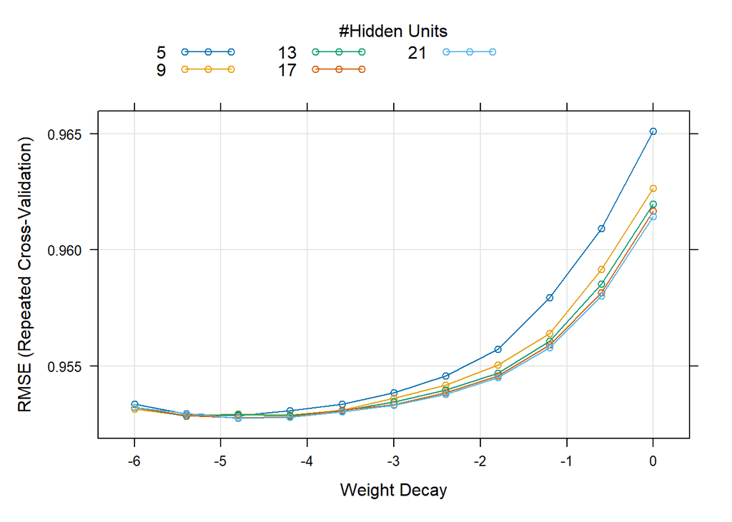

```r
set.seed(1234543)
nnet_grid <- expand.grid(size=c(5,9,13,17,21), decay=exp(seq(-6,0,length.out=11)))
mod_6 <- train(y~., method='nnet', metric = my_metric, trControl = my_ctrl_1,
               trace=F, tuneGrid = nnet_grid, preProcess=c('center', 'scale'), data = df_train_reg)
mod_6 %>% readr::write_rds("reg_mod_6.rds")
plot(mod_6, xTrans = log)
```

```r
mod_6$bestTune
```

```
##    size       decay
## 47   21 0.008229747
```

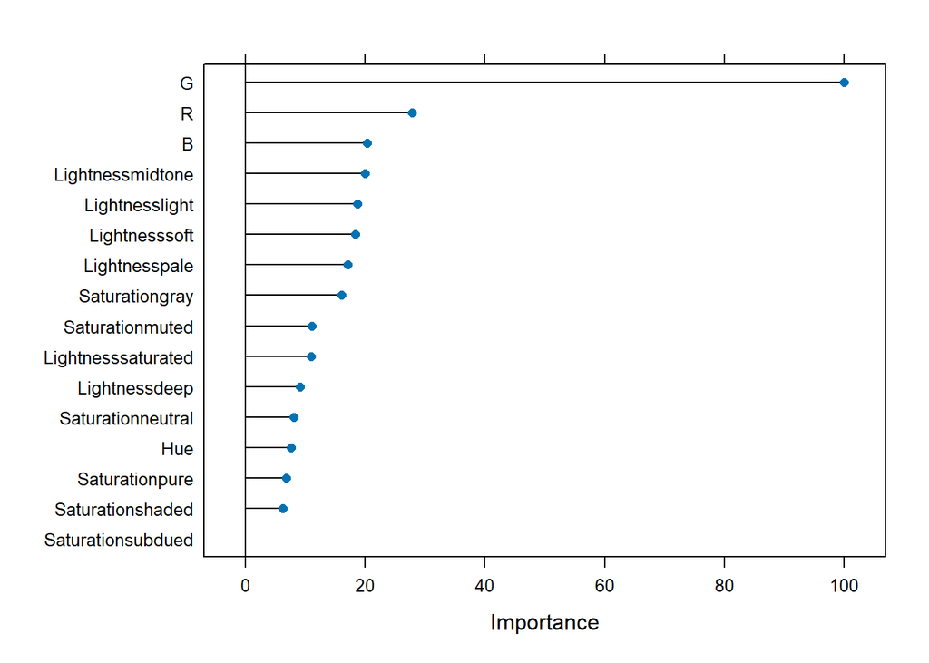

```r
plot(varImp(mod_6))
```

#### Model 7

**Random Forest**

```r
set.seed(123342)
rf_grid <- expand.grid(mtry = c(1:7),
                          KEEP.OUT.ATTRS = FALSE,
                        stringsAsFactors = FALSE)

mod_7 <- caret::train(y ~ ., method = 'rf',
                      data = df_train_reg,
                      importance = TRUE,
                      metric = my_metric,
                      trControl = my_ctrl_1,
                      tuneGrid = rf_grid)
mod_7 %>% readr::write_rds("reg_mod_7.rds")
mod_7
```

```
## Random Forest
##
## 668 samples
##   6 predictor
##
## No pre-processing
## Resampling: Cross-Validated (10 fold, repeated 5 times)
## Summary of sample sizes: 602, 601, 600, 601, 602, 602, ...
## Resampling results across tuning parameters:
##
##   mtry  RMSE        Rsquared   MAE
##   1     0.55625017  0.9324347  0.42968080
##   2     0.22755261  0.9764008  0.16682983
##   3     0.13221529  0.9899627  0.09735418
##   4     0.09826177  0.9941581  0.07172095
##   5     0.08278596  0.9957036  0.06074242
##   6     0.07473985  0.9964349  0.05540661
##   7     0.07066399  0.9967312  0.05273116
##
## RMSE was used to select the optimal model using the smallest value.
## The final value used for the model was mtry = 7.
```

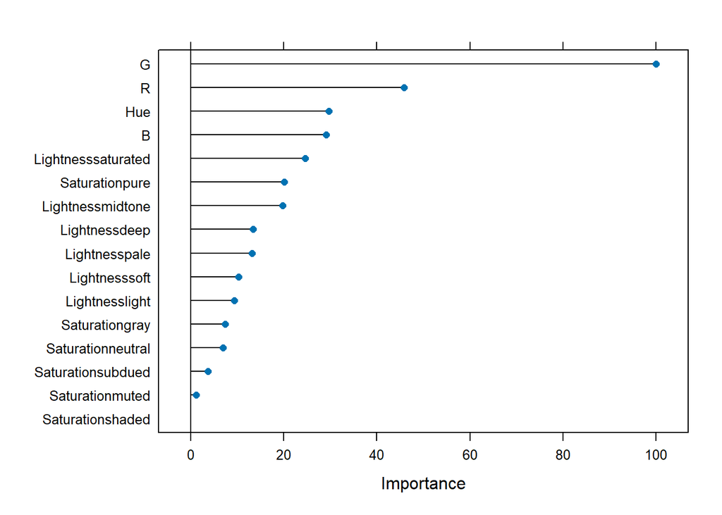

```r
plot(varImp(mod_7))
```

#### Model 8

**Gradient Boosted Tree**

```r
set.seed(12233)
xgb_default <- train( y ~ .,
                      data = df_train_reg,
                      method = 'xgbTree',
                      metric = my_metric,
                      trControl = my_ctrl_1,
                      verbosity = 0,
                      nthread = 1)
```

```r
set.seed(12234)
xgb_grid <- expand.grid(nrounds = c(25, 50, 100, 200, 400, 800),
                             max_depth = c(3, 6, 9),
                             eta =  c(0.0625*xgb_default$bestTune$eta,
                                      0.125*xgb_default$bestTune$eta,
                                      1.0*xgb_default$bestTune$eta),
                             gamma = xgb_default$bestTune$gamma,
                             colsample_bytree = xgb_default$bestTune$colsample_bytree,
                             min_child_weight = xgb_default$bestTune$min_child_weight,
                             subsample = xgb_default$bestTune$subsample)

mod_8 <- train( y ~ .,
                   data = df_train_reg,
                   method = 'xgbTree',
                   metric = my_metric,
                   tuneGrid = xgb_grid,
                   trControl = my_ctrl_1,
                   verbosity = 0,
                   nthread = 2)
mod_8 %>% readr::write_rds("reg_mod_8.rds")
```

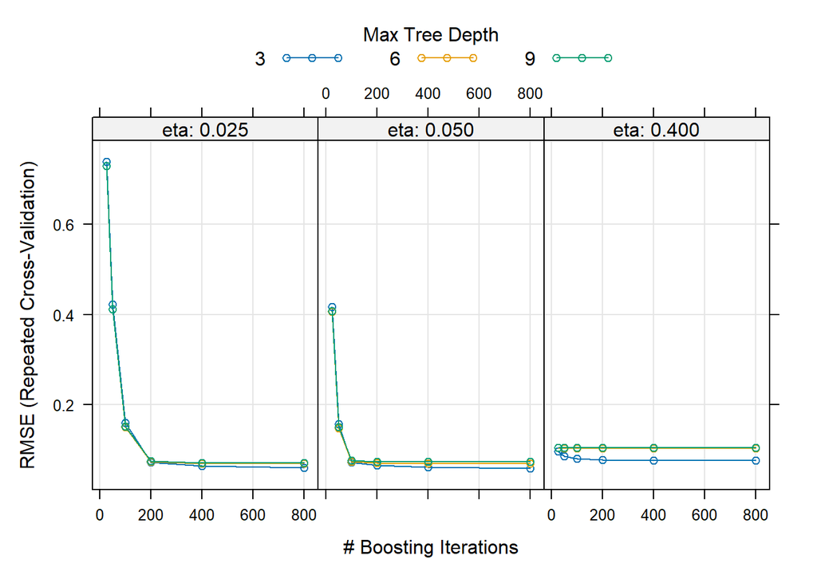

```r
plot(mod_8)
```

```r
mod_8$bestTune
```

```
##    nrounds max_depth  eta gamma colsample_bytree min_child_weight subsample
## 24     800         3 0.05     0              0.8                1         1
```

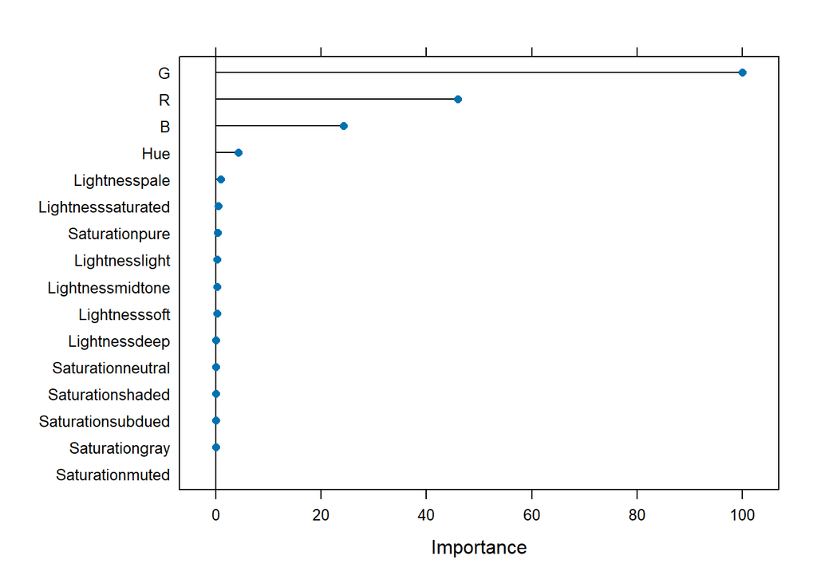

```r
plot(varImp(mod_8))
```

##### Model 9

**KNN**

```r
set.seed(3333)

knn_grid <- expand.grid(k = 1:16)


mod_9<- train(y ~ .,
                    data = df_train_reg,
                    method = "knn",
                    preProcess = c("center", "scale"),
                    metric = my_metric,
                    trControl = my_ctrl_1,
                tuneGrid = knn_grid)

mod_9 %>% readr::write_rds("reg_mod_9.rds")
```

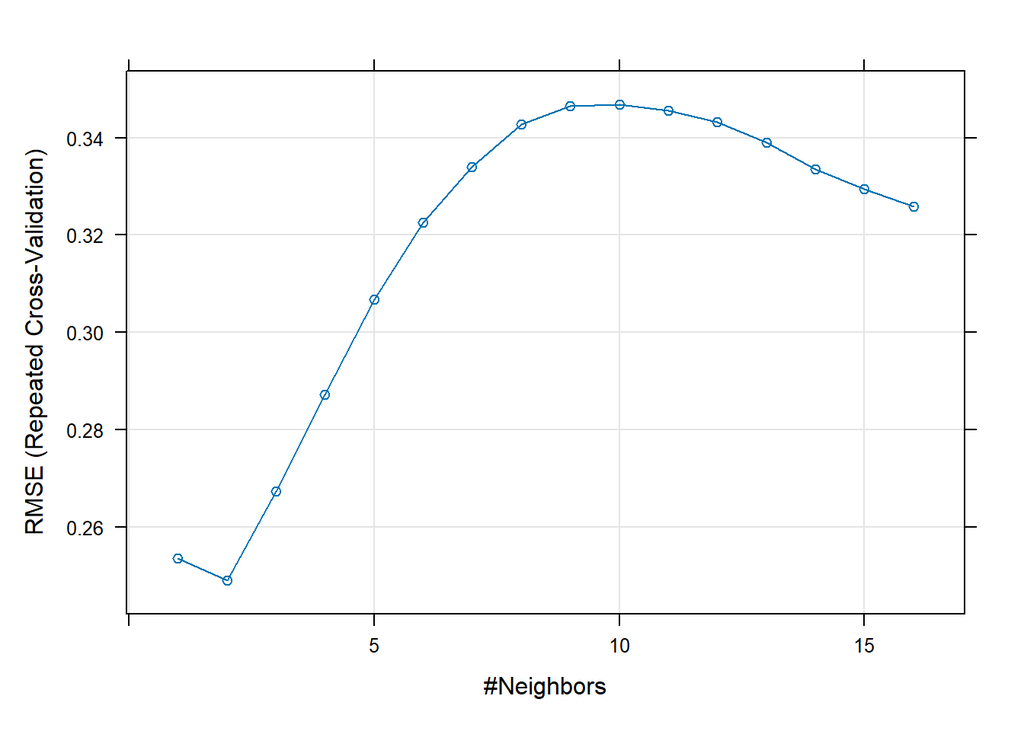

```r
plot(mod_9)
```

```r
mod_9$bestTune
```

```
##   k
## 2 2
```

The `k` value of `2` seems to be the best hyper parameter.

#### Model 10

**MARS**

```r
set.seed(123445)
mars_grid <- expand.grid( degree = 1:4,
                          nprune = seq(2, 100, length.out = 10) %>% floor())

mod_10 <- train(y~ ., method = 'earth', tuneGrid = mars_grid,
                preProcess=c("center", "scale"), metric = my_metric,
                trControl = my_ctrl_1, data = df_train_reg)
mod_10 %>% readr::write_rds("reg_mod_10.rds")
mod_10
```

```
## Multivariate Adaptive Regression Spline
##
## 668 samples
##   6 predictor
##
## Pre-processing: centered (16), scaled (16)
## Resampling: Cross-Validated (10 fold, repeated 5 times)
## Summary of sample sizes: 602, 602, 602, 600, 601, 601, ...
## Resampling results across tuning parameters:
##
##   degree  nprune  RMSE        Rsquared   MAE
##   1         2     0.37208557  0.8998400  0.30206257
##   1        12     0.07054878  0.9964639  0.04972216
##   1        23     0.07054878  0.9964639  0.04972216
##   1        34     0.07054878  0.9964639  0.04972216
```

[output cut: 39 more lines]

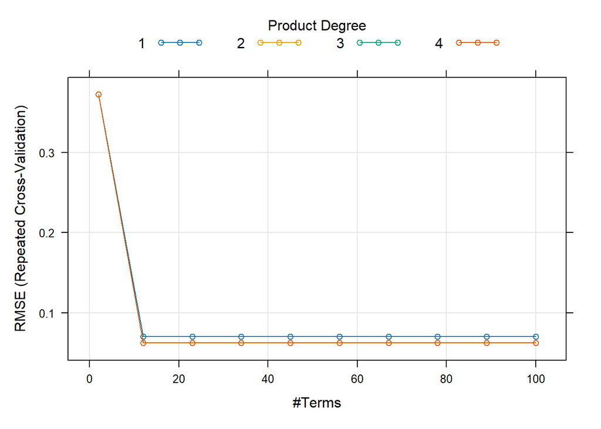

```r
plot(mod_10)
```

```r
mod_10$bestTune
```

```
##    nprune degree
## 12     12      2
```

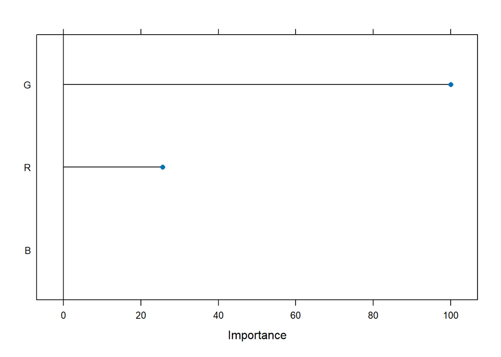

```r
plot(varImp(mod_10))
```

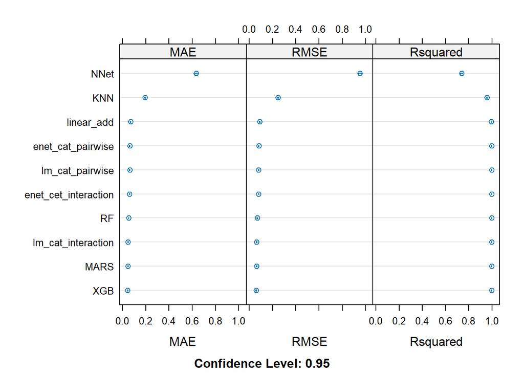

```r
model_compare <- resamples(list( linear_add = mod_1, lm_cat_pairwise = mod_2,
                                 lm_cat_interaction = mod_3, enet_cat_pairwise = mod_4,
                                 enet_cet_interaction = mod_5, NNet = mod_6,
                                RF = mod_7, XGB = mod_8,
                                KNN= mod_9, MARS = mod_10))
dotplot(model_compare)
```

As per the training set performance, `Gradient boosted tree` performed best followed by `MARS` seemed to be the best.

```r
evaluate_models <- function(models, df_test) {
  results <- data.frame(Model = character(), MSE = numeric(), RMSE = numeric(), MAE = numeric(), stringsAsFactors = FALSE)

  for (i in names(models)) {
    model <- models[[i]]
    model_name <- i

    # Predict on df_test

    predictions <- predict(model, newdata = df_test %>% select(-y ))
    mse_tr <- model$results$RMSE
    mae_tr <- model$results$MAE
    rsq_tr <- model$results$Rsquared
    # Calculate metrics
    mse <- mean((df_test$y - predictions)^2)
    rmse <- sqrt(mse)
    mae <- mean(abs(df_test$y - predictions))

    # Store results in the data frame
    result <- data.frame(Model = model_name, MSE = mse, RMSE = rmse, MAE = mae, mse_tr = mse_tr,
                         mae_tr = mae_tr, rsq_tr <- rsq_tr)
    results <- rbind(results, result)
  }

  return(results)
}

model_list <-list(linear_add = mod_1, lm_cat_pairwise = mod_2,
                                 lm_cat_interaction = mod_3, enet_cat_pairwise = mod_4,
                                 enet_cet_interaction = mod_5, NNet = mod_6,
                                RF = mod_7, XGB = mod_8,
                                KNN= mod_9, MARS = mod_10)

df_results <- evaluate_models(model_list, df_test_reg)
```

```r
 df_results
```

```
##                    Model         MSE       RMSE        MAE     mse_tr
## 1             linear_add 0.007612444 0.08724932 0.06410123 0.08999041
## 2        lm_cat_pairwise 0.006210873 0.07880909 0.05823475 0.08138167
## 3     lm_cat_interaction 0.003654540 0.06045280 0.04569849 0.06285145
## 4      enet_cat_pairwise 0.006896222 0.08304350 0.06195947 0.08192588
## 5      enet_cat_pairwise 0.006896222 0.08304350 0.06195947 0.08193247
## 6      enet_cat_pairwise 0.006896222 0.08304350 0.06195947 0.08195183
## 7      enet_cat_pairwise 0.006896222 0.08304350 0.06195947 0.08203075
## 8      enet_cat_pairwise 0.006896222 0.08304350 0.06195947 0.08218305
## 9      enet_cat_pairwise 0.006896222 0.08304350 0.06195947 0.08239680
## 10     enet_cat_pairwise 0.006896222 0.08304350 0.06195947 0.08266014
## 11     enet_cat_pairwise 0.006896222 0.08304350 0.06195947 0.08300308
## 12     enet_cat_pairwise 0.006896222 0.08304350 0.06195947 0.08347050
## 13     enet_cat_pairwise 0.006896222 0.08304350 0.06195947 0.08408663
## 14     enet_cat_pairwise 0.006896222 0.08304350 0.06195947 0.08487154
```

[output cut: 1337 more lines]

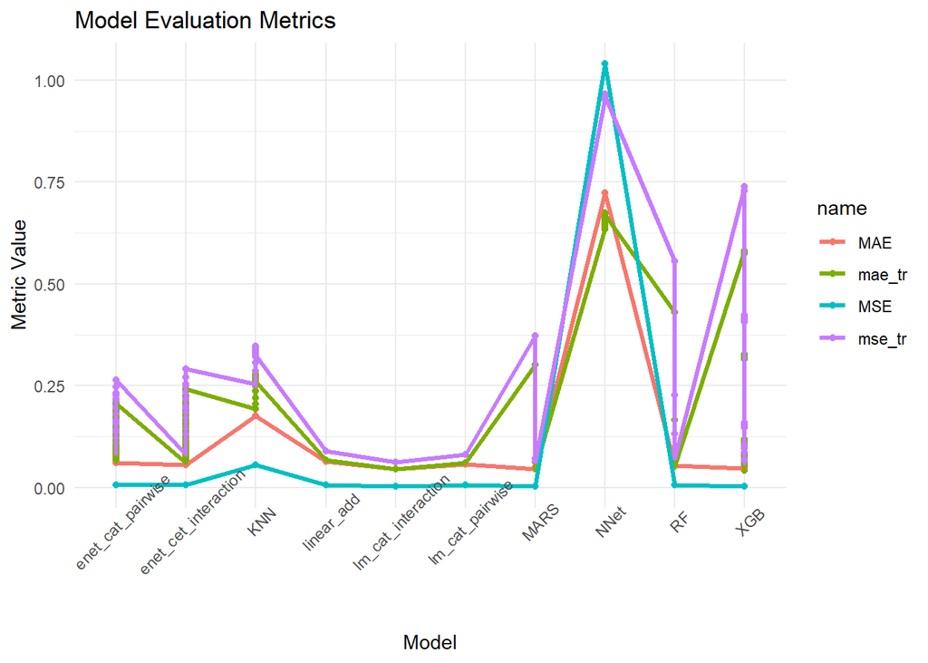

```r
df_results %>%
  tibble::rowid_to_column() %>%
  pivot_longer(c('MSE', 'MAE', 'mse_tr', 'mae_tr'), values_to = 'Value') %>%
  ggplot(aes(x = Model, y = Value, color = name, group = name)) +
  geom_point() +
  geom_line(size = 1.2) +
  labs(title = "Model Evaluation Metrics",
       x = "Model",
       y = "Metric Value") +
  theme_minimal() +
  theme(axis.text.x = element_text(angle = 45))
```

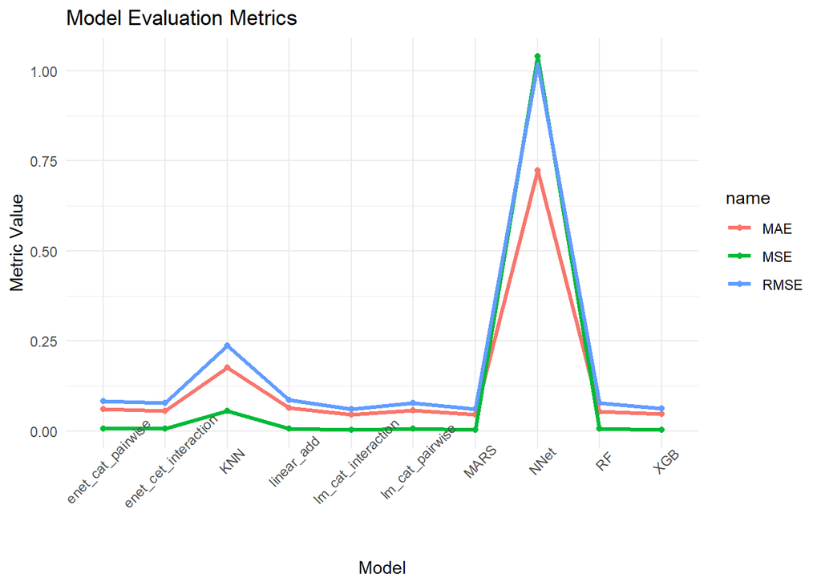

```r
df_results %>%
  tibble::rowid_to_column() %>%
  pivot_longer(c('MSE', 'MAE', 'RMSE'), values_to = 'Value') %>%
  ggplot(aes(x = Model, y = Value, color = name, group = name)) +
  geom_point() +
  geom_line(size = 1.2) +
  labs(title = "Model Evaluation Metrics",
       x = "Model",
       y = "Metric Value") +
  theme_minimal() +
  theme(axis.text.x = element_text(angle = 45))
```

```r
for (metric_col in c("MSE", "RMSE", "MAE")) {
  min_index <- which.min(df_results[[metric_col]])
  min_model <- df_results$Model[min_index]
  min_score <- df_results[[metric_col]][min_index]

  cat(sprintf("For %s, the model '%s' has the minimum score: %f\n", metric_col, min_model, min_score))
}
```

```
## For MSE, the model 'lm_cat_interaction' has the minimum score: 0.003655
## For RMSE, the model 'lm_cat_interaction' has the minimum score: 0.060453
## For MAE, the model 'MARS' has the minimum score: 0.045324
```

**Overall, the model `lm_cat_interaction` seems to perform better on the unseen data. So we can say that the model based on the Interaction of the categorical inputs with all continuous inputs main effects seems to fare better compared to the other models.**